# Validation of ascotraceR using two paddock sites data in southern Queensland

```r
library(ascotraceR)
library(foreach)
library(lubridate)
library(data.table)
library(future)
library(readxl)
library(dplyr)
library(ggplot2)
library(patchwork)
library(tictoc)
library(Metrics)
library(pROC)
library(epiR)
```

## Aims

To validate the *ascotraceR* spatio-temporal model with observed field data at two different locations.

## Experimental design

The experiments were conducted at two locations, Billa Billa and Tosari, Queensland, Australia. At each location, four replicate plots of disease free seed *Kyabra* were sown in 20 m x 20 m plots on 25 cm row spacing with a seeding rate of 40 seeds per square metre. There was a 4.5 m gap between each replicate plots–the gap was sown to wheat buffer to prevent disease spread among chickpea plots. To investigate the spatiotemporal development of Ascochyta blight, each plot was subdivided into a total of 24 observation quadrats at the distances of 3, 6 and 9 m (there were 8 observation quadrats at each distance), marked out at each corner with white pin markers, in a concentric arrangement around the primary infection foci. Each quadrat was assessed for the presence/absence of disease at fortnightly intervals.

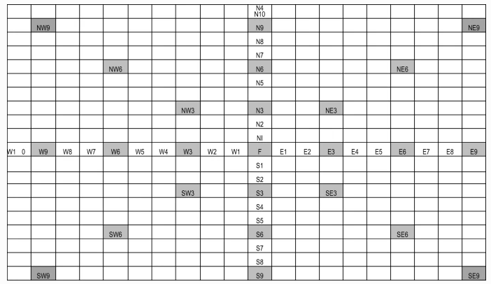

Experiment_Layout

## Billa Billa

### Billa Billa weather

Import Billa Billa’s weather data.

```r
Billa_Billa <-
   fread("data/2020_Billa_Billa_weather_data_ozforecast.csv")

Billa_Billa[, local_time := dmy_hm(local_time)]
```

The Billa Billa weather data needs formatting. To do that, we need to use `format_weather()` from *ascotraceR*.

```r
# specify the station coordinates of the Billa Billa weather station
Billa_Billa[, c("lat", "lon") := .(-28.1011505, 150.3307084)]

Billa_Billa <- format_weather(
  x = Billa_Billa,
  POSIXct_time = "local_time",
  temp = "mean_daily_temp",
  ws = "ws",
  wd_sd = "wd_sd",
  rain = "rain_mm",
  wd = "wd",
  station = "location",
  time_zone = "Australia/Brisbane",
  lon = "lon",
  lat = "lat"
)
```

### Run *ascotraceR* for Billa Billa

Since the model is stochastic, we’ll run it 20 times and compare the average outputs with the observed data.

```r
billa_list <- vector(mode = "list", length = 20)

n_cores <- 4
#create the cluster
my_cluster <- parallel::makeCluster(n_cores,
                                    type = "PSOCK")
doParallel::registerDoParallel(cl = my_cluster)
tic()
billa_list <-
  foreach(i = seq_len(length(billa_list))) %dopar% {
    ascotraceR::trace_asco(
      weather = Billa_Billa,
      paddock_length = 20,
      paddock_width = 20,
      initial_infection = as.POSIXct("2020-07-16"),
      sowing_date = as.POSIXct("2020-06-04"),
      harvest_date = as.POSIXct("2020-10-27"),
      time_zone = "Australia/Brisbane",
      seeding_rate = 40,
      gp_rr = 0.0065,
      spores_per_gp_per_wet_hour = 0.6,
      latent_period_cdd = 150,
      primary_inoculum_intensity = 200,
      primary_infection_foci = "centre"
    )
  }
toc()
```

```
## 100.843 sec elapsed
```

```r
parallel::stopCluster(cl = my_cluster)
```

### Sample relevant quadrats for quantitative model validation

The model predicted disease for the entire 20 x 20 m plots (i.e., the entire paddock). Since spatial and temporal disease progress in the field was observed only in selected quadrats (24 observation quadrats), we’ll sample the model’s predictions for the corrosponding 24 quadrats to compare the model prediction with the observed data from the field

```r
# create a single data.table object of the list output from `trace_asco()`
billa <- rbindlist(lapply(billa_list, tidy_trace), idcol = TRUE)

# create a new object of xy values scaled to match field observations with 0, 0
# at the middle rather than lower-left and add to `billa` object
xy_scaled <- CJ(-9:10, -9:10)
xy <- CJ(1:20, 1:20)
xy_scaled <- cbind(xy_scaled, xy)
colnames(xy_scaled) <- c("x_scaled", "y_scaled", "x", "y")
xy_scaled <-
  xy_scaled %>%
  mutate(
    quadrat = case_when(
      x_scaled == 0 & y_scaled == 0 ~ "F",
      x_scaled == 0 & y_scaled == 9 ~ "N9",
      x_scaled == 9 & y_scaled == 9 ~ "NE9",
      x_scaled == -9 & y_scaled == 9 ~ "NW9",
      x_scaled == 9 & y_scaled == 0 ~ "E9",
      x_scaled == 9 & y_scaled == -9 ~ "SE9",
      x_scaled == 0 & y_scaled == -9 ~ "S9",
      x_scaled == -9 & y_scaled == -9 ~ "SW9",
      x_scaled == -9 & y_scaled == 0 ~ "W9",
      x_scaled == 0 & y_scaled == 6 ~ "N6",
      x_scaled == 6 & y_scaled == 6 ~ "NE6",
      x_scaled == -6 & y_scaled == 6 ~ "NW6",
      x_scaled == 6 & y_scaled == 0 ~ "E6",
      x_scaled == 6 & y_scaled == -6 ~ "SE6",
      x_scaled == 0 & y_scaled == -6 ~ "S6",
      x_scaled == -6 & y_scaled == -6 ~ "SW6",
      x_scaled == -6 & y_scaled == 0 ~ "W6",
      x_scaled == 0 & y_scaled == 3 ~ "N3",
      x_scaled == 3 & y_scaled == 3 ~ "NE3",
      x_scaled == -3 & y_scaled == 3 ~ "NW3",
      x_scaled == 3 & y_scaled == 0 ~ "E3",
      x_scaled == 3 & y_scaled == -3 ~ "SE3",
      x_scaled == 0 & y_scaled == -3 ~ "S3",
      x_scaled == -3 & y_scaled == -3 ~ "SW3",
      x_scaled == -3 & y_scaled == 0 ~ "W3",
      TRUE ~ "other"
    )
  )

# create a summary of average infectious growing points by day and quadrat
billa_summary <-
  billa %>%
  left_join(xy_scaled, by = c("x", "y")) %>%
  group_by(i_date, quadrat, x_scaled, y_scaled) %>%
  summarise(infectious_gp = mean(infectious_gp))
```

### Disease progress over time

Taking the model predictions data frame, filter only the quadrats that were surveyed, mutate it to create a column that indicates whether a quadrat is infected or not, then group by `.id` and `i_date` and calculate the percent infection as the number of infected quadrats per paddock on `i_date` as `infected / number of rows`.

```r
billa <-
  billa %>%
  left_join(xy_scaled, by = c("x", "y")) %>%
  filter(quadrat != "other") %>%
  group_by(i_date, quadrat) %>%
  summarise(infectious_gp = mean(infectious_gp)) %>%
  mutate(infected = if_else(infectious_gp > 0, TRUE, FALSE, NA)) %>%
  group_by(i_date) %>%
  summarise(p_inf = sum(infected) / n())
```

Import Billa Billa’s field observations data to include in the graph.

```r
obs_dat <-
  setDT(read_xlsx("data/field_experiment_data.xlsx"))
```

Create a line graph of the observed disease progress over time & space with the model prediction over layered. The plot will display the proportion of infected quadrats on day “x”.

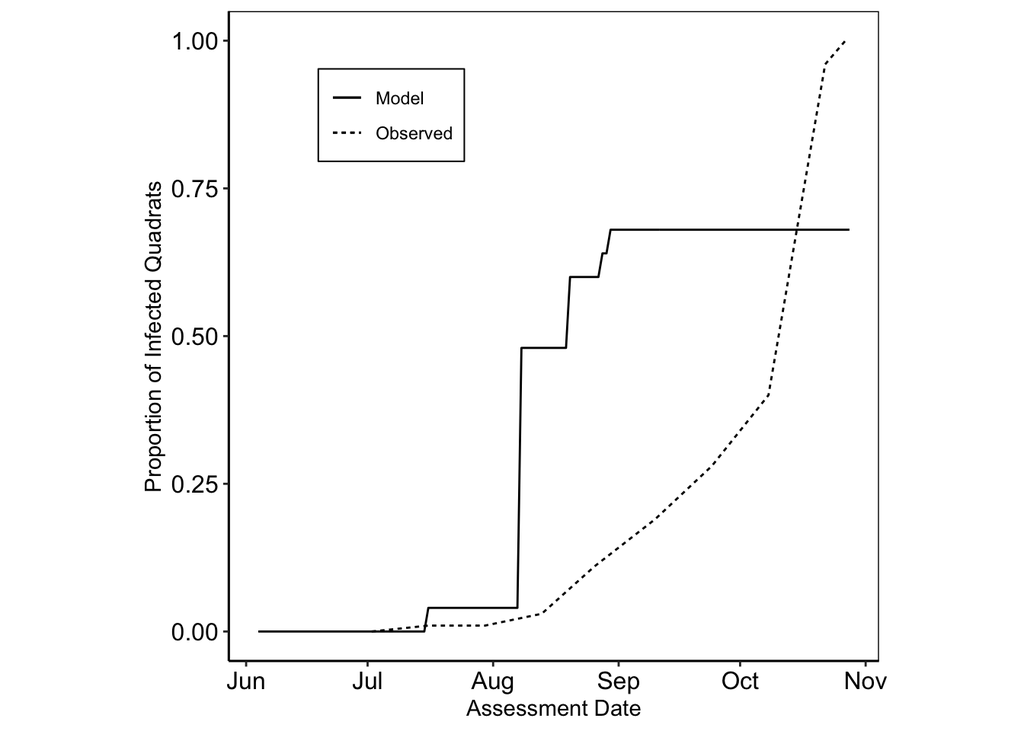

Proportion of infected quadrats over time at Billa Billa. The line represents the mean of 20 stochastic model runs

```r
obs_billa <-
  obs_dat %>%
  filter(location == "Billa Billa") %>%
  mutate(presence=ifelse(infected_plants > 0, 1, 0))

obs_billa <-
  obs_billa %>%
  mutate(assessment_date = as.Date(assessment_date)) %>%
  group_by(quadrat) %>%
  group_by(assessment_date) %>%
  summarise(i_perc = sum(presence == 1) / n())

billa_proportions <-
  ggplot(obs_billa, aes(x = assessment_date, y = i_perc)) +
  geom_line(aes(linetype = "Observed")) +
  geom_line(
    data = billa,
    aes(
      x = i_date,
      y = p_inf,
      linetype = "Model"
    ),
  ) +
  labs(x = "Assessment Date", y = "Proportion of Infected Quadrats") +
  theme_classic() +
  theme(
    legend.title = element_blank(),
    legend.spacing.y = unit(0, "mm"),
    panel.border = element_rect(colour = "black", fill = NA),
    aspect.ratio = 1,
    axis.text = element_text(colour = 1, size = 12),
    legend.background = element_blank(),
    legend.box.background = element_rect(colour = "black"),
    legend.position = c(0.25, 0.84)
  )

billa_proportions
```

## Tosari

### Tosari weather

Import Tosari’s weather data and format the time as a date object.

```r
Tosari <- fread("data/Tosari_2020_Goanna_weather.csv")[Time != "",]

# Format time to POSIXct
Tosari[, local_time :=
           as.POSIXct(
             unlist(
               lapply(strsplit(Time, " "),
                      function(x) paste(x[2:5],collapse = " "))
             ),
    format = "%B %d %Y %T",
    tz = "Australia/Brisbane")
       ]

# add station name
Tosari[ ,location := "tosari"]

# Remove erroring dates

Tosari <- Tosari[is.na(`Air Temp`)== FALSE, ]
```

Pass the data through `format_weather() function from *ascotraceR*.

```r
# specify the station coordinates of the Billa Billa weather station
Tosari[, c("lat", "lon") := .(-27.856248, 151.447391)]

Tosari <- format_weather(
  x = Tosari,
  POSIXct_time = "local_time",
  temp = "Air Temp",
  ws = "Avg Wind Speed",
  rain = "Rain",
  wd = "Avg Direction",
  station = "location",
  time_zone = "Australia/Brisbane",
  lon = "lon",
  lat = "lat"
)
```

### Run *ascotraceR* for Tosari

Run the model 20 times.

```r
tosari_list <- vector(mode = "list", length = 20)

n_cores <- 4
#create the cluster
my_cluster <- parallel::makeCluster(n_cores,
                                    type = "PSOCK")

doParallel::registerDoParallel(cl = my_cluster)
tic()
tosari_list <-
  foreach(i = seq_len(length(tosari_list))) %dopar% {
    ascotraceR::trace_asco(
      weather = Tosari,
      paddock_length = 20,
      paddock_width = 20,
      initial_infection = as.POSIXct("2020-07-30"),
      sowing_date = as.POSIXct("2020-06-27"),
      harvest_date = as.POSIXct("2020-11-05"),
      time_zone = "Australia/Brisbane",
      seeding_rate = 40,
      gp_rr = 0.0065,
      spores_per_gp_per_wet_hour = 0.6,
      latent_period_cdd = 150,
      primary_inoculum_intensity = 200,
      primary_infection_foci = "centre"
    )
  }
toc()
```

```
## 66.769 sec elapsed
```

```r
parallel::stopCluster(cl = my_cluster)
```

### Create data summary

```r
tosari <-
  rbindlist(lapply(tosari_list, tidy_trace), idcol = TRUE)

tosari_summary <-
  tosari %>%
  left_join(xy_scaled, by = c("x", "y")) %>%
  group_by(i_date, quadrat, x_scaled, y_scaled) %>%
  summarise(infectious_gp = mean(infectious_gp))
```

### Disease progress over time & space

Import Tosari’s field observations data.

```r
obs_tosari <-
  obs_dat %>%
  filter(location == "Tosari") %>%
  mutate(presence=ifelse(infected_plants > 0, 1, 0))
```

Plot the disease progress over time & space as the proportion of infected quadrats for Tosari, comparing the model runs with the observed values.

```r
tosari <-
  tosari %>%
  left_join(xy_scaled, by = c("x", "y")) %>%
  filter(quadrat != "other") %>%
  group_by(i_date, quadrat) %>%
  summarise(infectious_gp = mean(infectious_gp)) %>%
  mutate(infected = if_else(infectious_gp > 0, TRUE, FALSE, NA)) %>%
  group_by(i_date) %>%
  summarise(p_inf = sum(infected) / n())
```

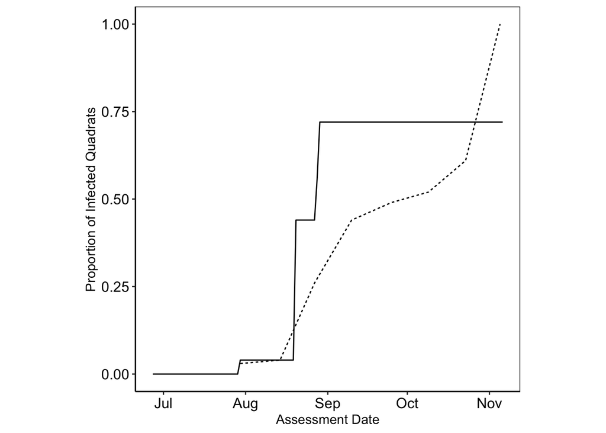

Proportion of infected quadrats over time at Tosari. The line represents the mean of 20 stochastic model runs

```r
obs_tosari <-
  obs_tosari %>%
  mutate(assessment_date = as.Date(assessment_date)) %>%
  group_by(assessment_date) %>%
  summarise(i_perc = sum(presence == 1) / n())

tosari_proportions <-
  ggplot(tosari, aes(x = i_date, y = p_inf)) +
  geom_line(aes(linetype = "Model")) +
  geom_line(data = obs_tosari,
            aes(x = assessment_date, y = i_perc, linetype = "Observed")) +
  labs(x = "Assessment Date", y = "Proportion of Infected Quadrats") +
  theme_classic() +
  theme(
    legend.position = "none",
    panel.border = element_rect(colour = "black", fill = NA),
    aspect.ratio = 1,
    axis.text = element_text(colour = 1, size = 12)
  )

tosari_proportions
```

## Combine plots

Using *patchwork* we can combine the plots for Billa Billa and Tosari into a single figure for publication.

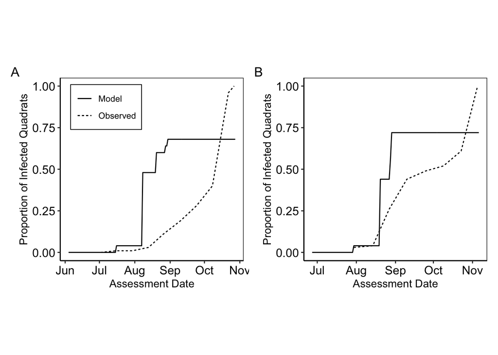

Observed proportion of diseased sites versus model predictions over time for, A) Billa Billa, Qld and B) Tosari, Qld. Observed data are shown with the dotted line. The model is shown with a solid line. The model line is the mean of 20 stochastic model runs using weather data for each respective site.

```r
billa_proportions +
  tosari_proportions +
  plot_annotation(tag_levels = 'A')
```

### Quantitative validation of the model for both locations

```r
# For observations, the observed proportion of infected quadrats for Tosari and Billa Billa for each assessment date can be accessed  via `obs_tosari$i_perc` and  `obs_billa$i_perc`

# For predictions, the model gives the output for the entire season. Since disease assessments were made ten times in Billa Billa and eight times in Tosari, predictions needs to be extracted for those days

# Extract predictions for Tosari for the corresponding observation assessment date
tosari$p_inf[[34]]
```

```
## [1] 0.04
```

```r
tosari$p_inf[[49]]
```

```
## [1] 0.04
```

```r
tosari$p_inf[[62]]
```

```
## [1] 0.44
```

```r
tosari$p_inf[[76]]
```

```
## [1] 0.72
```

```r
tosari$p_inf[[91]]
```

```
## [1] 0.72
```

```r
tosari$p_inf[[105]]
```

```
## [1] 0.72
```

```r
tosari$p_inf[[119]]
```

```
## [1] 0.72
```

```r
tosari$p_inf[[132]]
```

```
## [1] 0.72
```

```r
# combine into a single vector
predicted_tosari <- c(0.04, 0.04, 0.4, 0.72, 0.72, 0.72, 0.72, 0.72)


# Extract predictions for Billa Billa for the corresponding observation assessment date
billa$p_inf[[29]]
```

```
## [1] 0
```

```r
billa$p_inf[[43]]
```

```
## [1] 0.04
```

```r
billa$p_inf[[57]]
```

```
## [1] 0.04
```

```r
billa$p_inf[[71]]
```

```
## [1] 0.48
```

```r
billa$p_inf[[84]]
```

```
## [1] 0.6
```

```r
billa$p_inf[[99]]
```

```
## [1] 0.68
```

```r
billa$p_inf[[113]]
```

```
## [1] 0.68
```

```r
billa$p_inf[[126]]
```

```
## [1] 0.68
```

```r
billa$p_inf[[140]]
```

```
## [1] 0.68
```

```r
billa$p_inf[[145]]
```

```
## [1] 0.68
```

```r
# Combine into a single vector
predicted_billa <- c(0, 0.04, 0.04, 0.4, 0.6, 0.8, 0.8, 0.8, 0.8, 0.8)
```

I have put the above data into a spreadsheet to make a table for the ms, so I’ll import that

```r
# import observed and predicted proportions data
dat <- read_excel("data/proportions_obs_pred_data.xlsx") %>%
  mutate(observed_proportions = as.numeric(observed_proptions)) %>%
  mutate(predicted_proportions = as.numeric(predicted_proportions)) %>%
  mutate(assessment_number =  as.integer(assessment_number))
```

### Room mean squared error (RMSE)

```r
RMSE <- rmse(dat$predicted_proportions, dat$observed_proportions)
RMSE
```

```
## [1] 0.2874022
```

### Concordance correlation coefficient (CCC)

CCC is a metric of both consistency/correlation and accuracy, while RMSE is strictly for accuracy. CCC is used to determine an agreement for a CONTINEOUS measure obtained by two methods (e.g., observation and prediction). There is no assumption about data distribution, i.e., data does not need to be normally distributed. It is better than Pearson’s correlation, which ignores bias that might exist between observed and the predicted values. Pearson’s correlation measures linearity, while CCC measures an agreement between prediction and an observation. It’s also better than paired t test, which merely test whether the mean difference is significantly different from zero, but doesn’t provide an evidence that there is an agreement between means. The value ranges from 0 - 1. Value closer to 1 represents a better fit

```r
CCC <- epi.ccc(dat$predicted_proportions, dat$observed_proportions, ci = "z-transform", conf.level = 0.95)
CCC
```

```
## $rho.c
##         est   lower     upper
## 1 0.6360679 0.29295 0.8340488
##
## $s.shift
## [1] 1.121257
##
## $l.shift
## [1] -0.4173669
##
## $C.b
## [1] 0.9143658
##
## $blalt
##     mean delta
## 1  0.035  0.01
## 2  0.040  0.00
## 3  0.350  0.18
## 4  0.540  0.20
## 5  0.565  0.15
## 6  0.580  0.12
## 7  0.625  0.03
## 8  0.820 -0.36
## 9  0.000  0.00
## 10 0.025  0.03
## 11 0.025  0.03
## 12 0.215  0.37
## 13 0.355  0.49
## 14 0.495  0.61
## 15 0.540  0.52
## 16 0.600  0.40
## 17 0.880 -0.16
## 18 0.900 -0.20
##
## $sblalt
##         est  delta.sd      lower     upper
## 1 0.1344444 0.2613814 -0.3778538 0.6467427
##
## $nmissing
## [1] 0
```

### Receiver Operating Characteristic Curve (ROC)

ROC is used to measure the model ability to distinguish between the positive predictions (outcome of interest) and negative predictions (all other outcomes)

```r
# Create a ROC curve
ROC <- roc(dat$predicted_proportions, dat$observed_proportions)
ROC
```

```
##
## Call:
## roc.default(response = dat$predicted_proportions, predictor = dat$observed_proportions)
##
## Data: dat$observed_proportions in 1 controls (dat$predicted_proportions 0) < 4 cases (dat$predicted_proportions 0.04).
## Area under the curve: 1
```

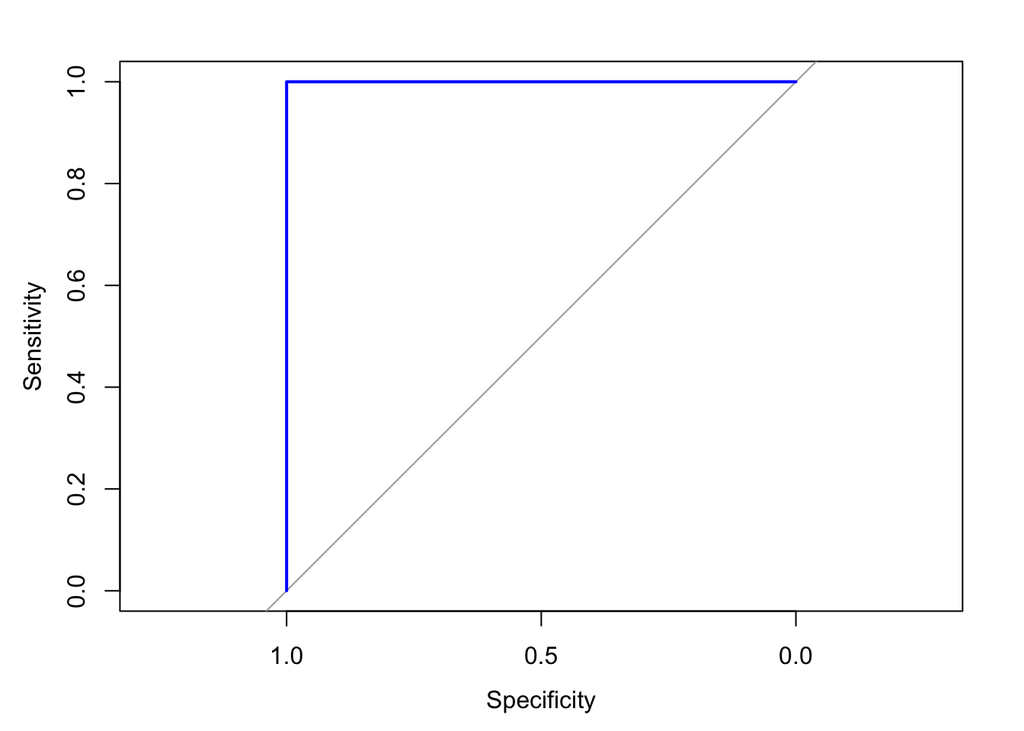

```r
# plot the ROC curve
plot(ROC, col = "blue")
```

### Area under the ROC curve

The ROC measure the area under the ROC curve. A perfect model has an AUC of 1, whereas an AUC value of 0.5 indicates that the model is no better than a random chance

```r
auc(ROC)
```

```
## Area under the curve: 1
```